# Canada Census - Population Ageing

Wendy Anthony

2022-08-22 21:26:27

# 1 Load Package

```r
# install.packages("")
library(tidyverse)
```

# 2 Data

## 2.1 Download Data for Victoria, BC

https://www12.statcan.gc.ca/census-recensement/2021/as-sa/fogs-spg/page.cfm?topic=2&lang=E&dguid=2021A00055917034#fogsTitle5  
Download Options (upper right arrow): csv https://www12.statcan.gc.ca/census-recensement/2021/as-sa/fogs-spg/alternative.cfm?topic=2&lang=E&dguid=2021A00055917034&objectId=5

## 2.3 Read Data

skip first 2 rows

```r
Victoria_pop_age_gender_2021 <- read.csv("Pop-Age-Gender-Victoria-2021-Census-2021A00055917034_5.csv",
                                         skip = 2, header = T)
BC_pop_2021 <- read.csv("BC-Pop-2021A000259_6.csv",
                                         skip = 2, header = T)
Canada_senior_pop_2021 <- read.csv("Canada-Senior-pop-percentage-2021A000259_5.csv",
                                         skip = 2, header = T)
```

skip last 12 rows

```r
Victoria_pop_age_gender_2021 <- head(Victoria_pop_age_gender_2021, -12)
BC_pop_2021 <- head(BC_pop_2021, -12)
Canada_senior_pop_2021 <- head(Canada_senior_pop_2021, -12)
```

## 2.4 Analyze data

```r
class(Victoria_pop_age_gender_2021)
```

```
## [1] "data.frame"
```

```r
str(Victoria_pop_age_gender_2021)
```

```
## 'data.frame':    42 obs. of  3 variables:
##  $ Age.groups       : chr  "0 to 4" "0 to 4" "5 to 9" "5 to 9" ...
##  $ Gender           : chr  "Women+" "Men+" "Women+" "Men+" ...
##  $ Population.counts: int  1400 1510 1440 1395 1365 1340 1340 1375 3475 2565 ...
```

```r
colnames(Victoria_pop_age_gender_2021)
```

```
## [1] "Age.groups"        "Gender"            "Population.counts"
```

```r
print(Victoria_pop_age_gender_2021)
```

```
##    Age.groups Gender Population.counts
## 1      0 to 4 Women+              1400
## 2      0 to 4   Men+              1510
## 3      5 to 9 Women+              1440
## 4      5 to 9   Men+              1395
## 5    10 to 14 Women+              1365
## 6    10 to 14   Men+              1340
## 7    15 to 19 Women+              1340
## 8    15 to 19   Men+              1375
## 9    20 to 24 Women+              3475
## 10   20 to 24   Men+              2565
## 11   25 to 29 Women+              4525
## 12   25 to 29   Men+              4235
## 13   30 to 34 Women+              4490
## 14   30 to 34   Men+              4545
```

[output cut: 28 more lines]

```r
glimpse(Victoria_pop_age_gender_2021)
```

```
## Rows: 42
## Columns: 3
## $ Age.groups        <chr> "0 to 4", "0 to 4", "5 to 9", "5 to 9", "10 to 14", …
## $ Gender            <chr> "Women+", "Men+", "Women+", "Men+", "Women+", "Men+"…
## $ Population.counts <int> 1400, 1510, 1440, 1395, 1365, 1340, 1340, 1375, 3475…
```

# 3 Data cleaning

## 3.1 Change values for Women+ Men+

```r
Victoria_pop_age_gender_2021[Victoria_pop_age_gender_2021 == "Women+"] <- "Women"
Victoria_pop_age_gender_2021[Victoria_pop_age_gender_2021 == "Men+"] <- "Men"

BC_pop_2021[BC_pop_2021 == "Women+"] <- "Women"
BC_pop_2021[BC_pop_2021 == "Men+"] <- "Men"
```

## 3.2 Change column name

```r
colnames(Victoria_pop_age_gender_2021) <- c("age_group", "gender", "pop")
colnames(BC_pop_2021) <- c("age_group", "gender", "pop")
```

## 3.3 Sort values of age_group to ensure 100+ appears in correct position

```r
Victoria_pop_age_gender_2021$age_group <- factor(Victoria_pop_age_gender_2021$age_group,
      levels = str_sort(unique(Victoria_pop_age_gender_2021$age_group), numeric = TRUE))
str(Victoria_pop_age_gender_2021)
```

```
## 'data.frame':    42 obs. of  3 variables:
##  $ age_group: Factor w/ 21 levels "0 to 4","5 to 9",..: 1 1 2 2 3 3 4 4 5 5 ...
##  $ gender   : chr  "Women" "Men" "Women" "Men" ...
##  $ pop      : int  1400 1510 1440 1395 1365 1340 1340 1375 3475 2565 ...
```

```r
BC_pop_2021$age_group <- factor(BC_pop_2021$age_group,
      levels = str_sort(unique(BC_pop_2021$age_group), numeric = TRUE))
str(BC_pop_2021)
```

```
## 'data.frame':    42 obs. of  3 variables:
##  $ age_group: Factor w/ 21 levels "0 to 4","5 to 9",..: 1 1 2 2 3 3 4 4 5 5 ...
##  $ gender   : chr  "Women" "Men" "Women" "Men" ...
##  $ pop      : int  105805 111015 118485 125810 123365 132425 122445 131245 143145 151505 ...
```

# 4 Senior Age Groups

## 4.1 Select rows by value

```r
Victoria_pop_age_gender_2021_seniors <-
  Victoria_pop_age_gender_2021[Victoria_pop_age_gender_2021$age_group %in%
          c("55 to 59", "60 to 64", "65 to 69", "70 to 74", "75 to 79",
            "80 to 84", "85 to 89", "90 to 94", "95 to 99", "100+"), ]

BC_pop_2021_seniors <-
  Victoria_pop_age_gender_2021[Victoria_pop_age_gender_2021$age_group %in%
          c("55 to 59", "60 to 64", "65 to 69", "70 to 74", "75 to 79",
            "80 to 84", "85 to 89", "90 to 94", "95 to 99", "100+"), ]
```

# 5 Pivot wider

```r
Victoria_pop_age_gender_2021_wide <- Victoria_pop_age_gender_2021 %>%
  pivot_wider(names_from = gender, values_from = pop)
```

# 6 Analyze wider data

```r
class(Victoria_pop_age_gender_2021_wide)
```

```
## [1] "tbl_df"     "tbl"        "data.frame"
```

```r
str(Victoria_pop_age_gender_2021_wide)
```

```
## tibble [21 × 3] (S3: tbl_df/tbl/data.frame)
##  $ age_group: Factor w/ 21 levels "0 to 4","5 to 9",..: 1 2 3 4 5 6 7 8 9 10 ...
##  $ Women    : int [1:21] 1400 1440 1365 1340 3475 4525 4490 3635 2945 2570 ...
##  $ Men      : int [1:21] 1510 1395 1340 1375 2565 4235 4545 3820 3035 2635 ...
```

```r
colnames(Victoria_pop_age_gender_2021_wide)
```

```
## [1] "age_group" "Women"     "Men"
```

```r
print(Victoria_pop_age_gender_2021_wide)
```

```
## # A tibble: 21 × 3
##    age_group Women   Men
##    <fct>     <int> <int>
##  1 0 to 4     1400  1510
##  2 5 to 9     1440  1395
##  3 10 to 14   1365  1340
##  4 15 to 19   1340  1375
##  5 20 to 24   3475  2565
##  6 25 to 29   4525  4235
##  7 30 to 34   4490  4545
##  8 35 to 39   3635  3820
##  9 40 to 44   2945  3035
## 10 45 to 49   2570  2635
## # … with 11 more rows
```

```r
glimpse(Victoria_pop_age_gender_2021_wide)
```

```
## Rows: 21
## Columns: 3
## $ age_group <fct> 0 to 4, 5 to 9, 10 to 14, 15 to 19, 20 to 24, 25 to 29, 30 t…
## $ Women     <int> 1400, 1440, 1365, 1340, 3475, 4525, 4490, 3635, 2945, 2570, …
## $ Men       <int> 1510, 1395, 1340, 1375, 2565, 4235, 4545, 3820, 3035, 2635, …
```

# 7 Sort values of age_group to ensure 100+ appears in correct position

factor, str_sort unique

```r
Victoria_pop_age_gender_2021_wide$age_group <- factor(Victoria_pop_age_gender_2021_wide$age_group,
  levels = str_sort(unique(Victoria_pop_age_gender_2021_wide$age_group), numeric = TRUE))
str(Victoria_pop_age_gender_2021_wide)
```

```
## tibble [21 × 3] (S3: tbl_df/tbl/data.frame)
##  $ age_group: Factor w/ 21 levels "0 to 4","5 to 9",..: 1 2 3 4 5 6 7 8 9 10 ...
##  $ Women    : int [1:21] 1400 1440 1365 1340 3475 4525 4490 3635 2945 2570 ...
##  $ Men      : int [1:21] 1510 1395 1340 1375 2565 4235 4545 3820 3035 2635 ...
```

# 8 Row index number

```r
Victoria_pop_age_gender_2021_wide$index <- as.numeric(row.names(Victoria_pop_age_gender_2021_wide))
Victoria_pop_age_gender_2021_wide[order(Victoria_pop_age_gender_2021_wide$index), ]
```

```
## # A tibble: 21 × 4
##    age_group Women   Men index
##    <fct>     <int> <int> <dbl>
##  1 0 to 4     1400  1510     1
##  2 5 to 9     1440  1395     2
##  3 10 to 14   1365  1340     3
##  4 15 to 19   1340  1375     4
##  5 20 to 24   3475  2565     5
##  6 25 to 29   4525  4235     6
##  7 30 to 34   4490  4545     7
##  8 35 to 39   3635  3820     8
##  9 40 to 44   2945  3035     9
## 10 45 to 49   2570  2635    10
## # … with 11 more rows
```

# 9 Plot data

## 9.1 plot

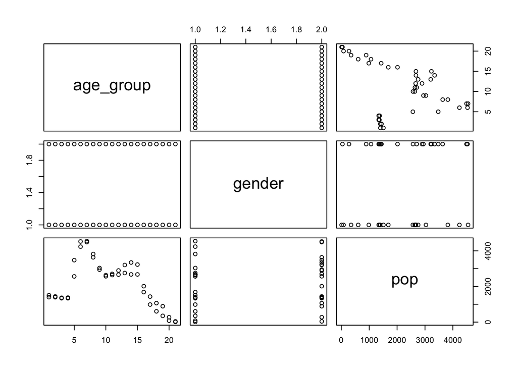

```r
plot(Victoria_pop_age_gender_2021)
```

## 9.2 ggplot data stacked bar Victoria, BC

PROBLEM: age grouping not correct e.g. 100+ comes after 10 to 14 >>  
Sort values of age_group to ensure 100+ appears in correct position  
factor, str_sort unique

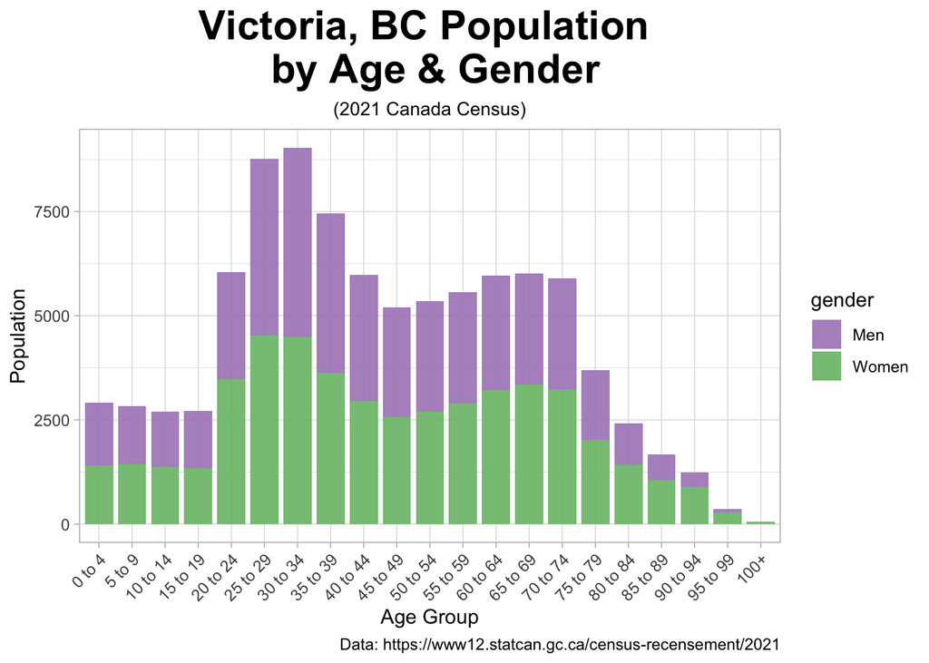

```r
# colour_palette <- c("#d8b365", "#5ab4ac") # Colour brewer color-blind safe
colour_palette <- c("#af8dc3", "#7fbf7b") # Colour brewer color-blind safe

Victoria_pop_age_gender_2021 %>%
  ggplot(aes(x = age_group, y = pop, fill = gender)) +
  geom_bar(stat = "identity", alpha = 0.95, width = 0.85)  + # width = 1 no space between bars
  theme_light() +
  theme(
    plot.title = element_text(size = rel(2), face = "bold", hjust = 0.5),
    plot.subtitle = element_text(size = rel(.92), hjust = 0.5),
    axis.text.x = element_text(angle = 45, hjust = 1)
    ) +
  scale_fill_manual(values = colour_palette) +
  labs(title = "Victoria, BC Population \n by Age & Gender",
       subtitle = "(2021 Canada Census)",
       x = "Age Group",
       y = "Population",
       caption = "Data: https://www12.statcan.gc.ca/census-recensement/2021")
```

## 9.3 ggplot data stacked bar British Columbia

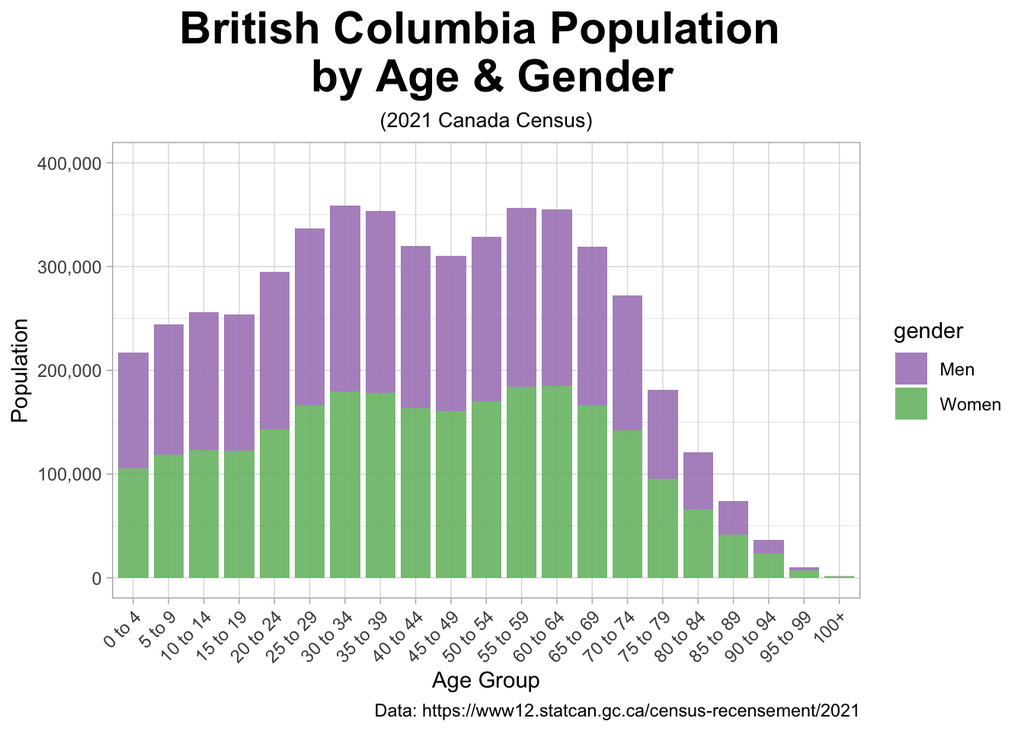

```r
# colour_palette <- c("#d8b365", "#5ab4ac") # Colour brewer color-blind safe
colour_palette <- c("#af8dc3", "#7fbf7b") # Colour brewer color-blind safe

BC <- BC_pop_2021 %>%
  ggplot(aes(x = age_group, y = pop, fill = gender)) +
  geom_bar(stat = "identity", alpha = 0.95, width = 0.85)  + # width = 1 no space between bars
  theme_light() +
  theme(
    plot.title = element_text(size = rel(2), face = "bold", hjust = 0.5),
    plot.subtitle = element_text(size = rel(.92), hjust = 0.5),
    axis.text.x = element_text(angle = 45, hjust = 1)
    ) +
  scale_fill_manual(values = colour_palette) +
  labs(title = "British Columbia Population \n by Age & Gender",
       subtitle = "(2021 Canada Census)",
       x = "Age Group",
       y = "Population",
       caption = "Data: https://www12.statcan.gc.ca/census-recensement/2021")

BC + scale_y_continuous(limits = c(0, 400000), labels = scales::comma)
```

```r
        # to avoid scientific notation
```

## 9.4 ggplot data stacked column with labels for BC

need to find the cumulative sum for each stack  
https://r-graphics.org/recipe-bar-graph-labels#cb84-7

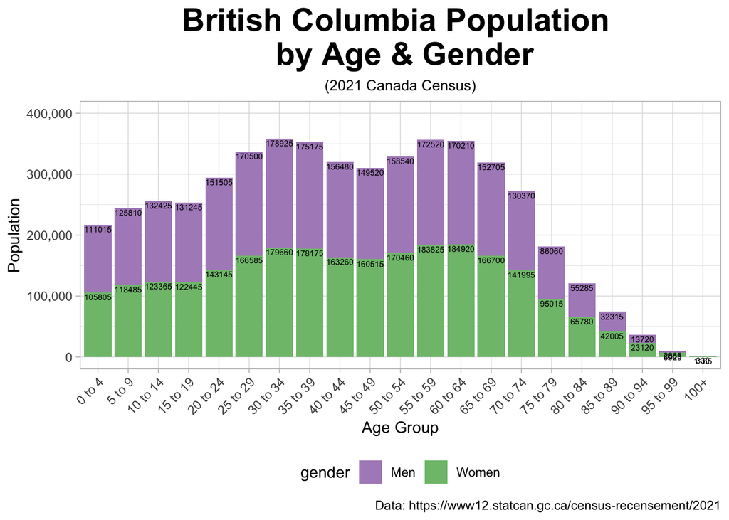

```r
# colour_palette <- c("#d8b365", "#5ab4ac") # Colour brewer color-blind safe

# get cumulative sum
BC_pop_2021 <- BC_pop_2021 %>%
  group_by(age_group) %>%
  mutate(label_y = cumsum(pop))

colour_palette <- c("#af8dc3", "#7fbf7b") # Colour brewer color-blind safe

BC_lab <- BC_pop_2021 %>%
  ggplot(aes(x = age_group, y = pop, fill = gender)) +
  geom_col()  +
  geom_text(aes(y = label_y, label = pop), vjust = 1.25, size = 2) +
  theme_light() +
  theme(
    plot.title = element_text(size = rel(2), face = "bold", hjust = 0.5),
    plot.subtitle = element_text(size = rel(.92), hjust = 0.5),
    axis.text.x = element_text(angle = 45, hjust = 1),
    legend.position = "bottom"
    ) +
  scale_fill_manual(values = colour_palette) +
  labs(title = "British Columbia Population \n by Age & Gender",
       subtitle = "(2021 Canada Census)",
       x = "Age Group",
       y = "Population",
       caption = "Data: https://www12.statcan.gc.ca/census-recensement/2021")

BC_lab + scale_y_continuous(limits = c(0, 400000), labels = scales::comma)
```

## 9.5 ggplot data stacked column with labels

need to find the cumulative sum for each stack  
https://r-graphics.org/recipe-bar-graph-labels#cb84-7

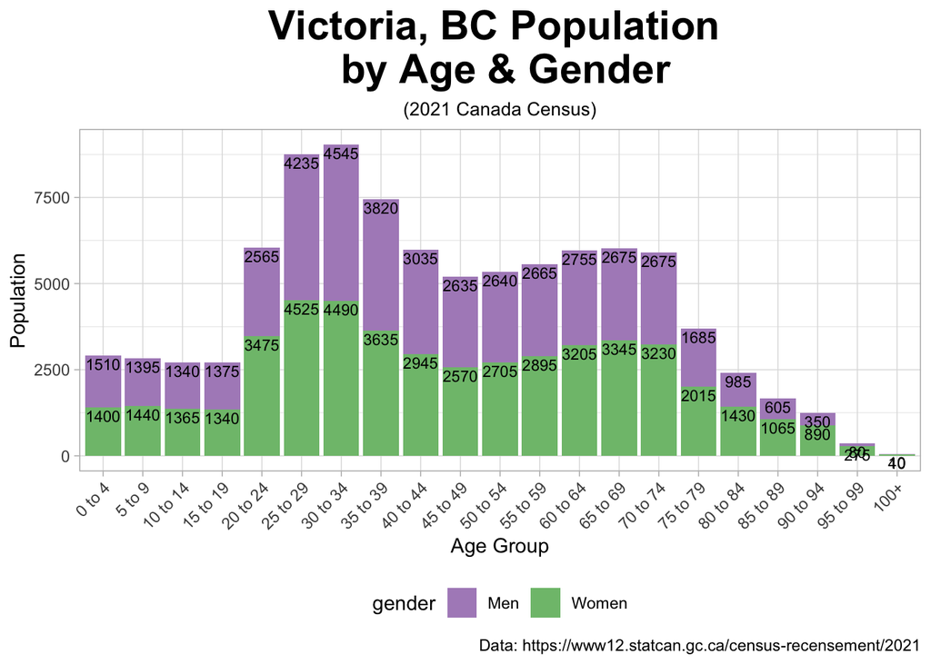

```r
# colour_palette <- c("#d8b365", "#5ab4ac") # Colour brewer color-blind safe

# get cumulative sum
Victoria_pop_age_gender_2021 <- Victoria_pop_age_gender_2021 %>%
  group_by(age_group) %>%
  mutate(label_y = cumsum(pop))

colour_palette <- c("#af8dc3", "#7fbf7b") # Colour brewer color-blind safe

Victoria_pop_age_gender_2021 %>%
  ggplot(aes(x = age_group, y = pop, fill = gender)) +
  geom_col()  +
  geom_text(aes(y = label_y, label = pop), vjust = 1.25, size = 3) +
  theme_light() +
  theme(
    plot.title = element_text(size = rel(2), face = "bold", hjust = 0.5),
    plot.subtitle = element_text(size = rel(.92), hjust = 0.5),
    axis.text.x = element_text(angle = 45, hjust = 1),
    legend.position = "bottom"
    ) +
  scale_fill_manual(values = colour_palette) +
  labs(title = "Victoria, BC Population \n by Age & Gender",
       subtitle = "(2021 Canada Census)",
       x = "Age Group",
       y = "Population",
       caption = "Data: https://www12.statcan.gc.ca/census-recensement/2021")
```

## 9.6 ggplot data - Victoria BC

PROBLEM: age grouping not correct e.g. 100+ comes after 10 to 14 >>  
Sort values of age_group to ensure 100+ appears in correct position  
factor, str_sort unique

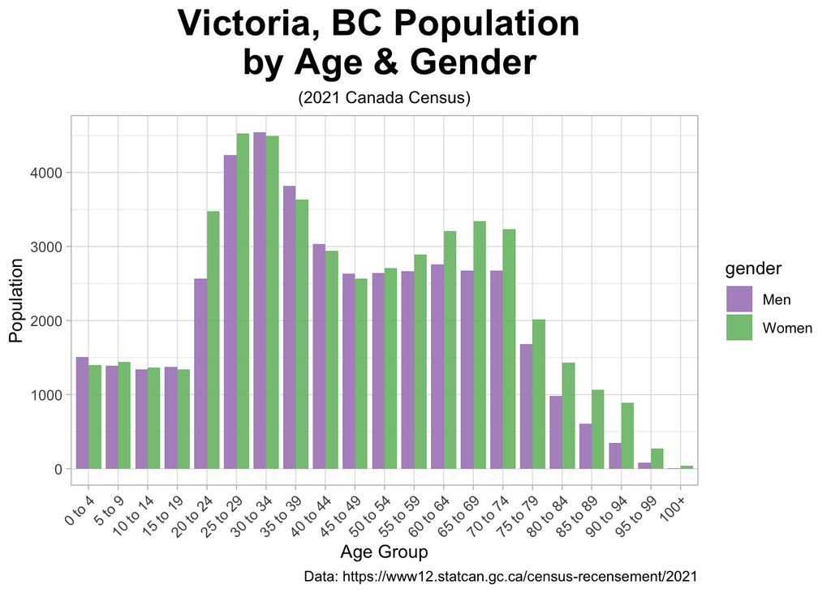

```r
# colour_palette <- c("#d8b365", "#5ab4ac") # Colour brewer color-blind safe
colour_palette <- c("#af8dc3", "#7fbf7b") # Colour brewer color-blind safe

Victoria_pop_age_gender_2021 %>%
  ggplot(aes(x = age_group, y = pop, fill = gender)) +
  geom_bar(stat = "identity", position = position_dodge(), alpha = 0.95, width = 0.85)  +
              # width = 1 no space between bars
  theme_light() +
  theme(
    plot.title = element_text(size = rel(2), face = "bold", hjust = 0.5),
    plot.subtitle = element_text(size = rel(.92), hjust = 0.5),
    axis.text.x = element_text(angle = 45, hjust = 1)
    ) +
  scale_fill_manual(values = colour_palette) +
  labs(title = "Victoria, BC Population \n by Age & Gender",
       subtitle = "(2021 Canada Census)",
       x = "Age Group",
       y = "Population",
       caption = "Data: https://www12.statcan.gc.ca/census-recensement/2021")
```

## 9.7 ggplot data - BC

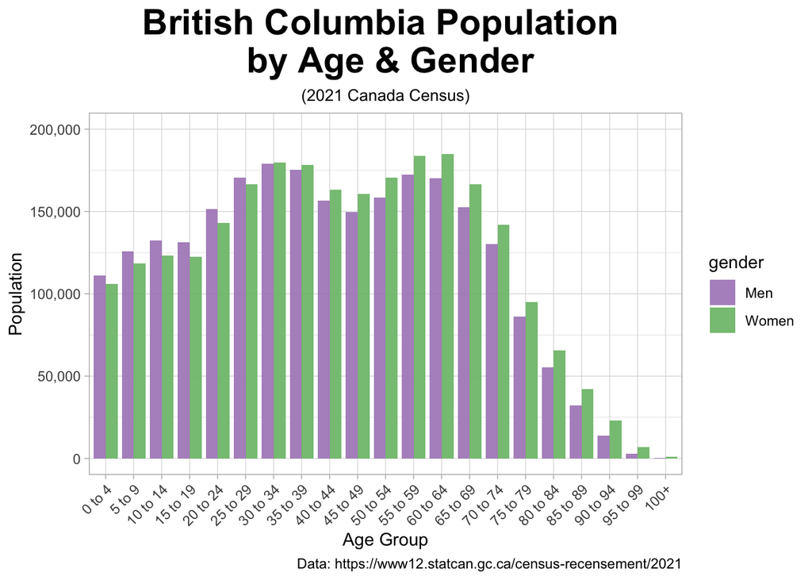

```r
# colour_palette <- c("#d8b365", "#5ab4ac") # Colour brewer color-blind safe
colour_palette <- c("#af8dc3", "#7fbf7b") # Colour brewer color-blind safe

BC_pop_2021 %>%
  ggplot(aes(x = age_group, y = pop, fill = gender)) +
  geom_bar(stat = "identity", position = position_dodge(), alpha = 0.95, width = 0.85)  +
              # width = 1 no space between bars
  theme_light() +
  theme(
    plot.title = element_text(size = rel(2), face = "bold", hjust = 0.5),
    plot.subtitle = element_text(size = rel(.92), hjust = 0.5),
    axis.text.x = element_text(angle = 45, hjust = 1)
    ) +
  scale_fill_manual(values = colour_palette) +
  labs(title = "British Columbia Population \n by Age & Gender",
       subtitle = "(2021 Canada Census)",
       x = "Age Group",
       y = "Population",
       caption = "Data: https://www12.statcan.gc.ca/census-recensement/2021") +
  scale_y_continuous(limits = c(0, 200000), labels = scales::comma)
```

## 9.8 ggplot data for seniors

PROBLEM: age grouping not correct e.g. 100+ comes after 10 to 14 >>  
Sort values of age_group to ensure 100+ appears in correct position  
factor, str_sort unique

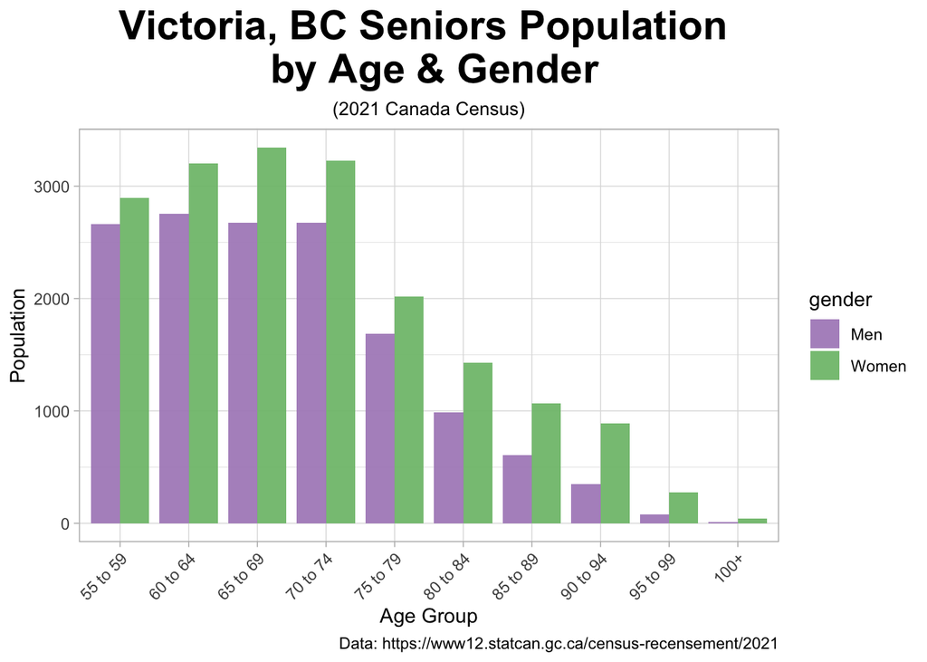

```r
# colour_palette <- c("#d8b365", "#5ab4ac") # Colour brewer color-blind safe
colour_palette <- c("#af8dc3", "#7fbf7b") # Colour brewer color-blind safe

Victoria_pop_age_gender_2021_seniors %>%
  ggplot(aes(x = age_group, y = pop, fill = gender)) +
  geom_bar(stat = "identity", position = position_dodge(), alpha = 0.95, width = 0.85)  +
                      # wideth = 1 no space between bars
  theme_light() +
  theme(
    plot.title = element_text(size = rel(2), face = "bold", hjust = 0.5),
    plot.subtitle = element_text(size = rel(.92), hjust = 0.5),
    axis.text.x = element_text(angle = 45, hjust = 1)
    ) +
  scale_fill_manual(values = colour_palette) +
  labs(title = "Victoria, BC Seniors Population \n by Age & Gender",
       subtitle = "(2021 Canada Census)",
       x = "Age Group",
       y = "Population",
       caption = "Data: https://www12.statcan.gc.ca/census-recensement/2021")
```

## 9.9 ggplot data for seniors with data labels

https://intellipaat.com/community/16343/how-to-put-labels-over-geombar-for-each-bar-in-r-with-ggplot2

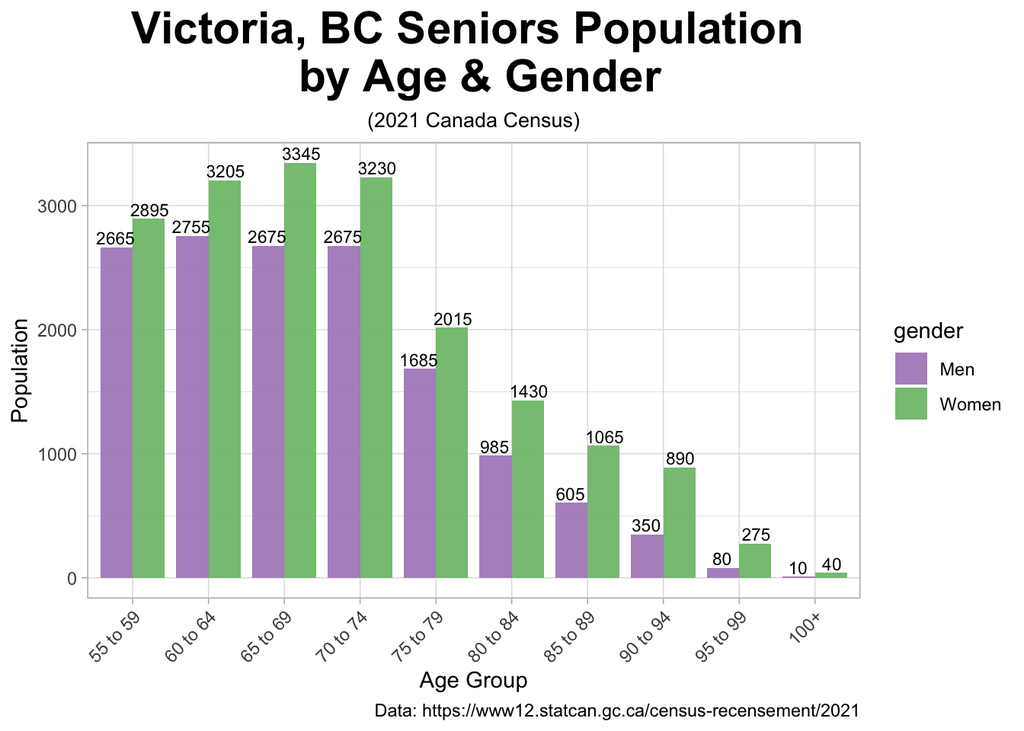

```r
# colour_palette <- c("#d8b365", "#5ab4ac") # Colour brewer color-blind safe
colour_palette <- c("#af8dc3", "#7fbf7b") # Colour brewer color-blind safe

Victoria_pop_age_gender_2021_seniors %>%
  ggplot(aes(x = age_group, y = pop, fill = gender)) +
  geom_bar(stat = "identity", position = "dodge", alpha = 0.95, width = 0.85)  +
                        # wideth = 1 no space between bars
  geom_text(aes(label = pop), size = 3, position = position_dodge(width = 0.9), vjust = -0.25) +
                                    # vjust negative shows above bar
  theme_light() +
  theme(
    plot.title = element_text(size = rel(2), face = "bold", hjust = 0.5),
    plot.subtitle = element_text(size = rel(.92), hjust = 0.5),
    axis.text.x = element_text(angle = 45, hjust = 1)
    ) +
  scale_fill_manual(values = colour_palette) +
  labs(title = "Victoria, BC Seniors Population \n by Age & Gender",
       subtitle = "(2021 Canada Census)",
       x = "Age Group",
       y = "Population",
       caption = "Data: https://www12.statcan.gc.ca/census-recensement/2021")
```

## 9.10 ggplot data for seniors with data labels, legend at bottom

https://intellipaat.com/community/16343/how-to-put-labels-over-geombar-for-each-bar-in-r-with-ggplot2

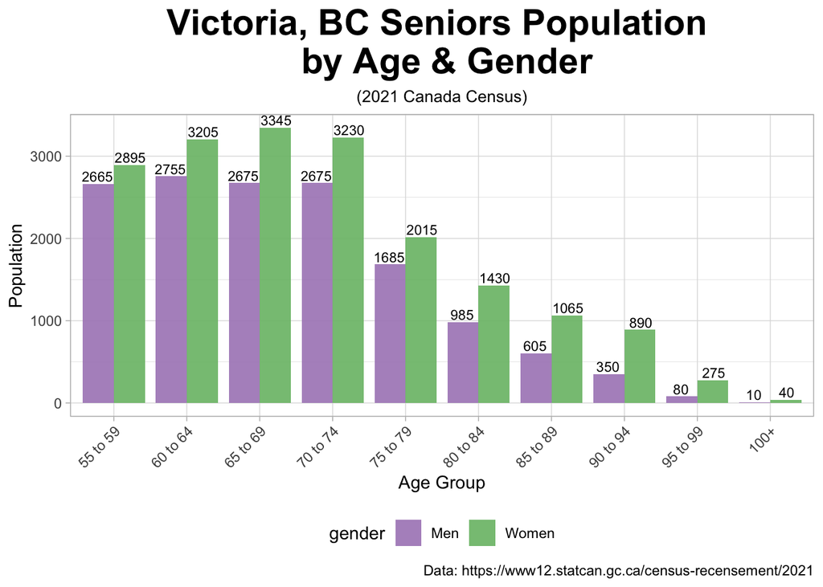

```r
# colour_palette <- c("#d8b365", "#5ab4ac") # Colour brewer color-blind safe
colour_palette <- c("#af8dc3", "#7fbf7b") # Colour brewer color-blind safe

Victoria_pop_age_gender_2021_seniors %>%
  ggplot(aes(x = age_group, y = pop, fill = gender)) +
  geom_bar(stat = "identity", position = "dodge", alpha = 0.95, width = 0.85)  +
                            # wideth = 1 no space between bars
  geom_text(aes(label = pop), size = 3, position = position_dodge(width = 0.9), vjust = -0.25) +
                                # vjust negative shows above bar
  theme_light() +
  theme(
    plot.title = element_text(size = rel(2), face = "bold", hjust = 0.5),
    plot.subtitle = element_text(size = rel(.92), hjust = 0.5),
    axis.text.x = element_text(angle = 45, hjust = 1),
    legend.position = "bottom"
    ) +
  scale_fill_manual(values = colour_palette) +
  labs(title = "Victoria, BC Seniors Population \n by Age & Gender",
       subtitle = "(2021 Canada Census)",
       x = "Age Group",
       y = "Population",
       caption = "Data: https://www12.statcan.gc.ca/census-recensement/2021")
```

## 9.11 ggplot data for pivot wide Women

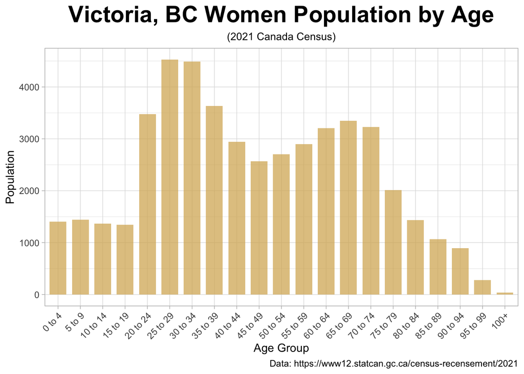

```r
Victoria_pop_age_gender_2021_wide %>%
  ggplot(aes(x = age_group, y = Women)) +
  geom_bar(stat = "identity", position = position_dodge(),
           alpha = 0.75, width = 0.75, fill = "#d8b365")  + # wideth = 1 no space between bars
  theme_light() +
  theme(
    plot.title = element_text(size = rel(2), face = "bold", hjust = 0.5),
    plot.subtitle = element_text(size = rel(.92), hjust = 0.5),
    axis.text.x = element_text(angle = 45, hjust = 1),
    ) +
  labs(title = "Victoria, BC Women Population by Age",
       subtitle = "(2021 Canada Census)",
       x = "Age Group",
       y = "Population",
       caption = "Data: https://www12.statcan.gc.ca/census-recensement/2021")
```

## 9.12 ggplot data for pivot wide Men

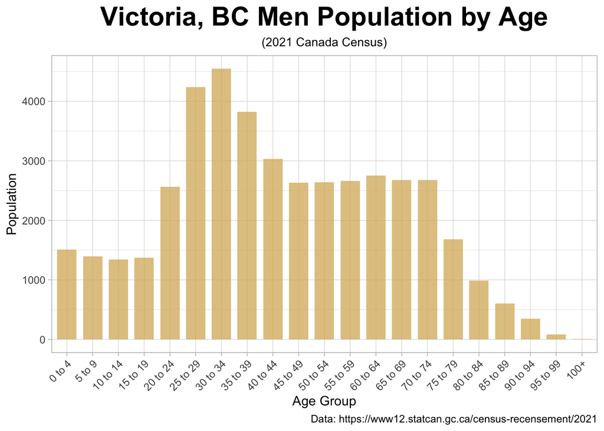

```r
Victoria_pop_age_gender_2021_wide %>%
  ggplot(aes(x = age_group, y = Men)) +
  geom_bar(stat = "identity", position = position_dodge(),
           alpha = 0.75, width = 0.75, fill = "#d8b365")  + # wideth = 1 no space between bars
  theme_light() +
  theme(
    plot.title = element_text(size = rel(2), face = "bold", hjust = 0.5),
    plot.subtitle = element_text(size = rel(.92), hjust = 0.5),
    axis.text.x = element_text(angle = 45, hjust = 1),
    ) +
  labs(title = "Victoria, BC Men Population by Age",
       subtitle = "(2021 Canada Census)",
       x = "Age Group",
       y = "Population",
       caption = "Data: https://www12.statcan.gc.ca/census-recensement/2021")
```